# CRAN and R-Packages

Lee F Richardson  
Jan 30, 2018

1. What is CRAN? Why use it?
2. R CMD check
3. Travis, Winbuilder, and Submitting

All code online at: https://github.com/leerichardson/leeR

### What is CRAN?

“The Comprehensive R Archive Network (CRAN) is a collection of sites which carry identical material, consisting of the R distribution(s), the **contributed extensions**, documentation for R, and binaries.”

- CRAN servers all over the world, called *mirrors*
- CRAN mirrors have **contributed extensions** (R-packages)

### Why put your package on CRAN?

- Authenticity
- Quality Control (external standards/checks)
- More likely to be used (`install.packages`)

### CRAN vs. Github

- CRAN, Github are platforms for sharing R packages
- CRAN more reliable, takes more effort
- Github easy, no external checks
- Choice depends on project

### It all comes down to R CMD check

`R CMD check`: Terminal command, checks package

- Run in console with the `devtools` package:

```r
  devtools::check()
```

`devtools::check()` also:

- Automatically runs documentation,
- Builds package (`R CMD build`) first

### Three Types: Notes, Warnings, and Errors

`R CMD check` gives three types of feedback:

- **Errors**: Most Severe
- **Warnings**: Medium Severe
- **Notes**: Least Severe

Details on each check: 1.3.1 Writing R Extensions

### Example 1: Checking the Tests

Say we add a new test to our package:

```r
test_that("our function works", {
  expect_equal(2, 2)
  expect_equal(1, 2)
})
```

What will `devtools::check()` do?

### Error: Tests don't run!

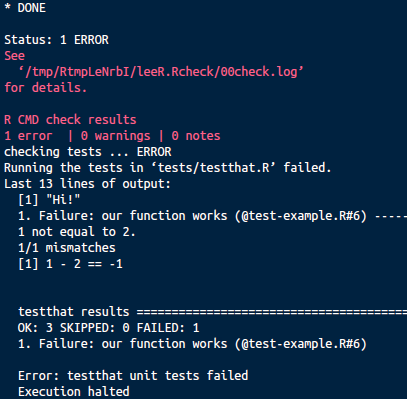

### Example 2: Checking documentation

```r
#' Print a string!
#'
#' @param string to print
#' @param fake parameter
#'
#' @return A printed string
#' @examples
#' to_print <- "Hello, world!
#' leeR_demo(to_print)
#'
leeR_demo <- function(string) {
  print(string)
}
```

`devtools::check()`?

### Warning: Function/Docs don't match

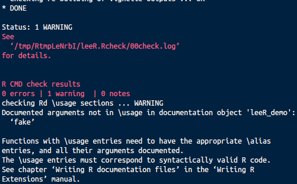

### Example 3: Anything wrong here?

```r
#' Multivariate normal random numbers
#'
#' @param n number of observations
#' @param mean_vec vector of means
#'
#' @return n x length(mean_vec) of
#' observations from a multivariate normal
generate_mvnorm <- function(n, mean_vec) {
  rmvnorm(n = n, x = mean_vec)
}
```

`devtools::check()`…

### Note: Using an external package

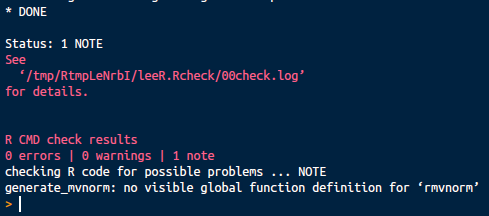

```r
  devtools::use_package("mvtnorm")
  mvtnorm::rmvnorm
```

### After R CMD check passes, we need to...

- Remember to keep running R CMD check
- Make sure R CMD check passes on multiple operating systems

Solve with Continuous Integration and Winbuilder!

### Continuous Integration automates checks

What is Continuous Integration (CI)?

“Continuous Integration is the practice of merging in small code changes frequently - rather than merging in a large change at the end of a development cycle. The goal is to build healthier software by developing and testing in smaller increments. This is where Travis CI comes in.” - https://docs.travis-ci.com/user/for-beginners

- Travis is a “Continuous Integration” (CI) service
- Use Tracis `R CMD check` on every Github push

### How to integrate Travis with R-package

- Add to package with:

```r
  devtools::use_travis("/home/lee/Dropbox/leeR")
```

- Creates `.travis.yml` in source directory
- Get Travis account, link Github account
- Push to Github
- E-mail will tell you if it passed

### Travis builds and checks on Ubuntu

[figure not shown]

### WinBuilder builds and checks on Windows

- Travis checks package on **Ubuntu**
- Winbuilder checks package on **Windows**

```r
  devtools::build_win()
```

- Build, submits to https://win-builder.r-project.org/
- E-mail in 30-60 minutes with results

### WinBuilder builds and checks on Windows

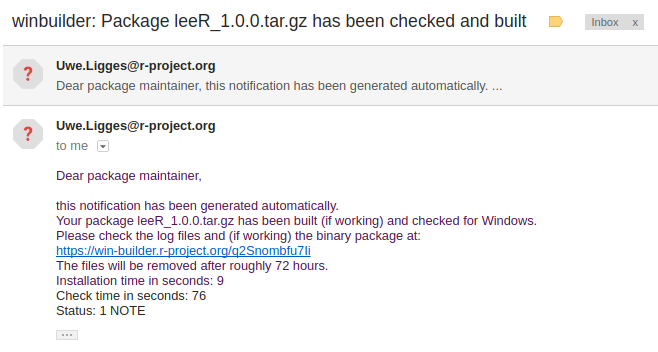

### Submitting the finished package

1. `R CMD check` passes
2. Travis CI passes
3. Winbuilder passes

Once these steps are complete:

- Follow http://r-pkgs.had.co.nz/release.html#release-check
- Aim, aim, Let it fly!

```r
  devtools::release()
```

Submits this form https://cran.r-project.org/submit.html

### Conclusions

- It all comes down to **R CMD check**
- Know goals, prepare early for CRAN
- Travis, winbuilder are useful external tools
- Big victory for the devtools/R-packages book

### Resources

- http://r-pkgs.had.co.nz/check.html
- https://cran.r-project.org/doc/manuals/r-release/R-exts.html#useDynLib
- http://www.hep.by/gnu/r-patched/r-faq/R-FAQ_20.html
- https://cran.r-project.org/web/packages/policies.html

Two good lists of all the checks are

- http://r-pkgs.had.co.nz/check.html
- Section 1.3.1 of Writing R Extensions